# Assignment 1

Stephen Allen

August 5, 2015

```r
georgia = read.csv('georgia2000.csv', header=TRUE)
attach(georgia)
summary(georgia)
```

```
##       county       ballots           votes            equip
##  APPLING :  1   Min.   :   881   Min.   :   832   LEVER  :74
##  ATKINSON:  1   1st Qu.:  3694   1st Qu.:  3506   OPTICAL:66
##  BACON   :  1   Median :  6712   Median :  6299   PAPER  : 2
##  BAKER   :  1   Mean   : 16927   Mean   : 16331   PUNCH  :17
##  BALDWIN :  1   3rd Qu.: 12251   3rd Qu.: 11846
##  BANKS   :  1   Max.   :280975   Max.   :263211
##  (Other) :153
##       poor            urban           atlanta            perAA
##  Min.   :0.0000   Min.   :0.0000   Min.   :0.00000   Min.   :0.0000
##  1st Qu.:0.0000   1st Qu.:0.0000   1st Qu.:0.00000   1st Qu.:0.1115
##  Median :0.0000   Median :0.0000   Median :0.00000   Median :0.2330
##  Mean   :0.4528   Mean   :0.2642   Mean   :0.09434   Mean   :0.2430
##  3rd Qu.:1.0000   3rd Qu.:1.0000   3rd Qu.:0.00000   3rd Qu.:0.3480
##  Max.   :1.0000   Max.   :1.0000   Max.   :1.00000   Max.   :0.7650
##
##       gore             bush
##  Min.   :   249   Min.   :   271
##  1st Qu.:  1386   1st Qu.:  1804
##  Median :  2326   Median :  3597
##  Mean   :  7020   Mean   :  8929
##  3rd Qu.:  4430   3rd Qu.:  7468
##  Max.   :154509   Max.   :140494
##
```

```r
MisCount=(ballots-votes)/votes
summary(MisCount)
```

```
##    Min. 1st Qu.  Median    Mean 3rd Qu.    Max.
## 0.00000 0.02859 0.04149 0.04655 0.05985 0.23170
```

Next we look at the plots of miscounted votes versus certain statistics about those counties. It is hard to distinguish clear implications from these plots although it sees that miscounted votes seem to occur more frewuently in poor and rural communities.

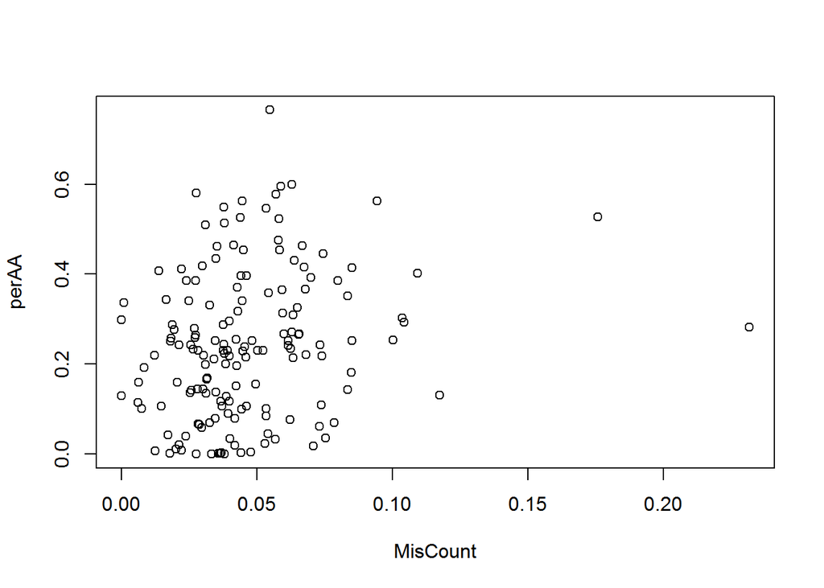

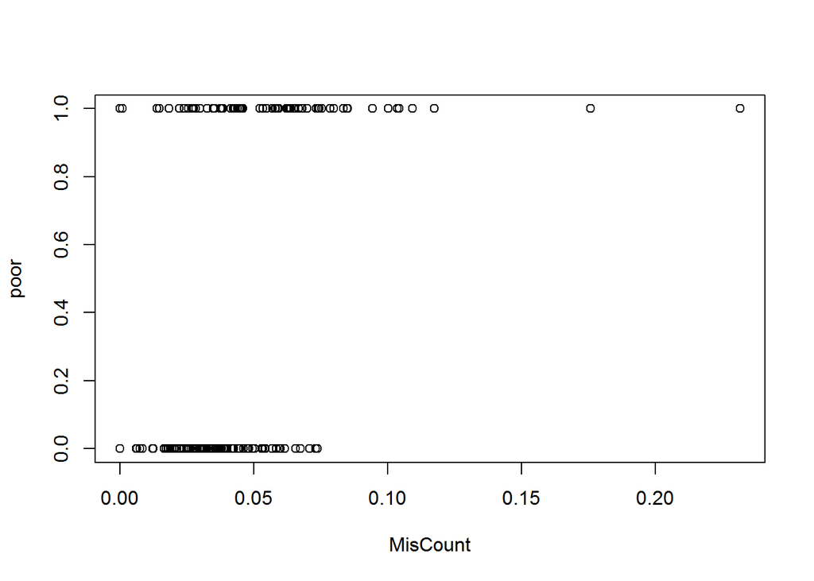

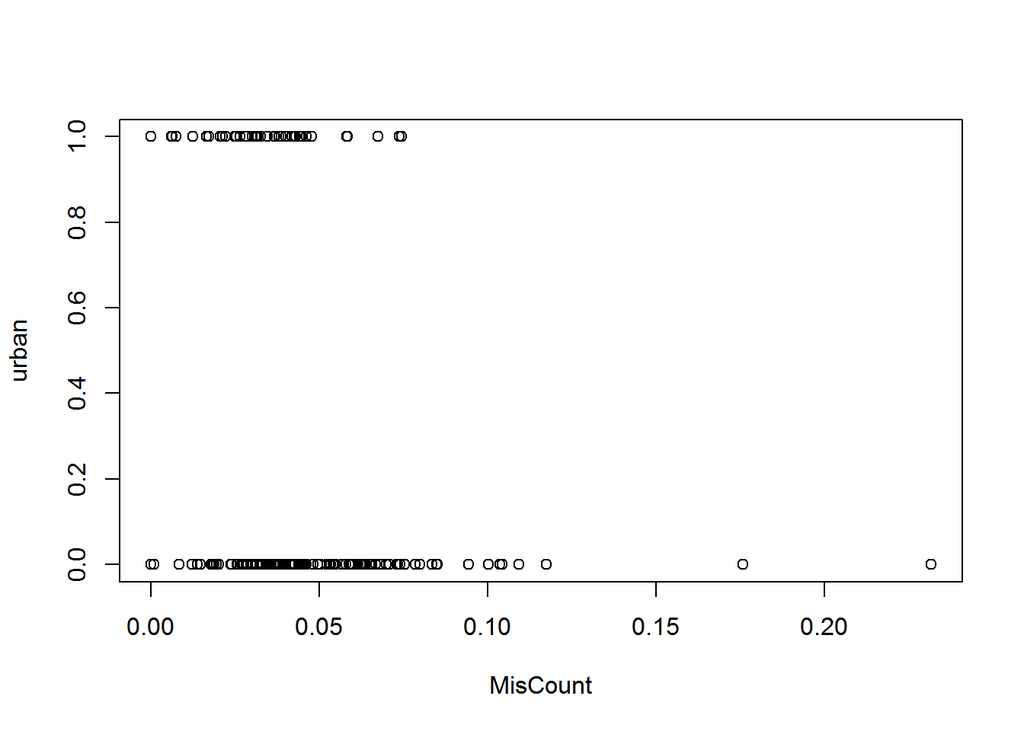

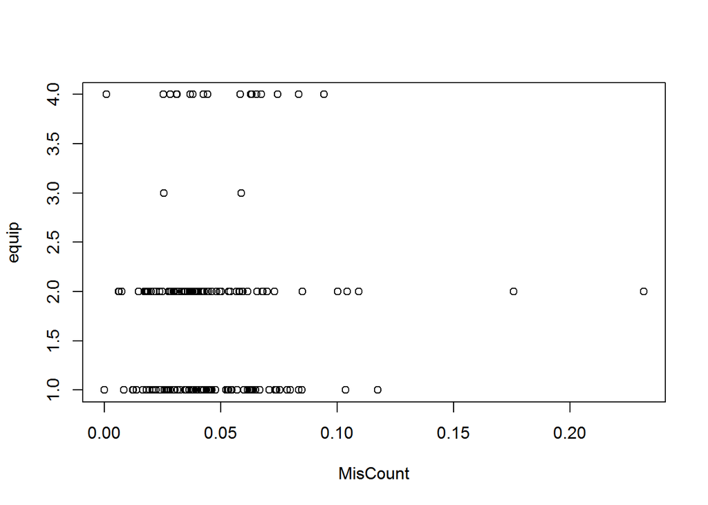

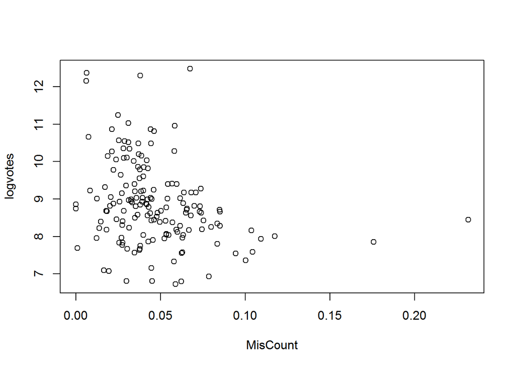

Finally we run a simple linear regression to see what variables have significant relationships with the response, MisCount. As it turns out, there appear to be more miscouned votes in poor areas and the error rate is higher in areas that record a large number of votes. It also seems that optical voting equipment has a higher error rate than other equipment.  
It also turns out that optical equipment is actually used less frequently in more African American Communities.

```r
linear.votes = lm(MisCount~ .-county,georgia)
summary(linear.votes)
```

```
##
## Call:
## lm(formula = MisCount ~ . - county, data = georgia)
##
## Residuals:
##       Min        1Q    Median        3Q       Max
## -0.064994 -0.012707 -0.002552  0.010109  0.151392
##
## Coefficients:
##                Estimate Std. Error t value Pr(>|t|)
## (Intercept)   2.957e-02  5.080e-03   5.822 3.52e-08 ***
## ballots       1.227e-05  3.341e-06   3.674 0.000334 ***
## votes         2.589e-06  7.369e-06   0.351 0.725791
## equipOPTICAL  1.656e-02  4.615e-03   3.587 0.000454 ***
## equipPAPER   -1.282e-02  1.789e-02  -0.717 0.474814
## equipPUNCH    1.300e-02  7.624e-03   1.706 0.090162 .
## poor          2.100e-02  5.424e-03   3.873 0.000161 ***
## urban        -6.503e-03  5.796e-03  -1.122 0.263688
## atlanta      -1.078e-02  9.725e-03  -1.108 0.269622
## perAA         1.175e-02  1.620e-02   0.725 0.469476
## gore         -1.598e-05  9.104e-06  -1.755 0.081304 .
## bush         -1.552e-05  9.079e-06  -1.710 0.089458 .
## ---
## Signif. codes:  0 '***' 0.001 '**' 0.01 '*' 0.05 '.' 0.1 ' ' 1
##
## Residual standard error: 0.02479 on 147 degrees of freedom
## Multiple R-squared:  0.3171, Adjusted R-squared:  0.266
## F-statistic: 6.205 on 11 and 147 DF,  p-value: 2.456e-08
```

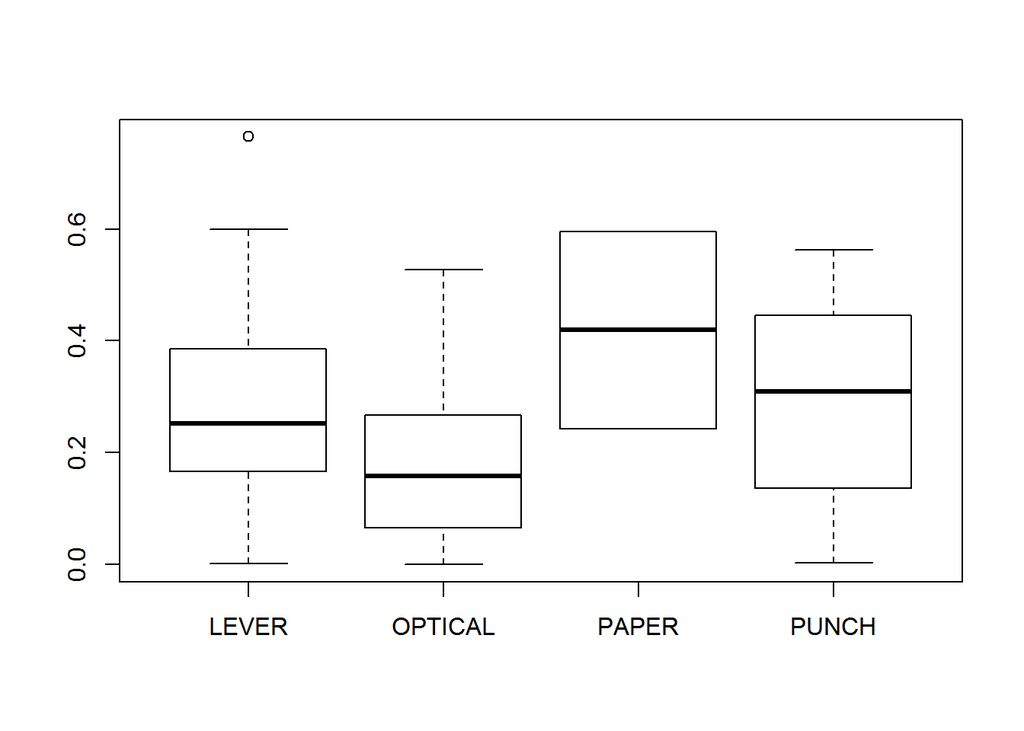

```r
plot(equip,perAA)
```

…………………………………………………………………

Now let us consider 3 portfolio options. We will create 3 portfolios out of financial assests: US domestic equities (SPY: the S&P 500 stock index) US Treasury bonds (TLT) Investment-grade corporate bonds (LQD) Emerging-market equities (EEM) Real estate (VNQ)

First we load in the appropriate data:

```r
library(fImport)
```

```r
library(foreach)
library(mosaic)
mystocks = c("SPY", "TLT", "LQD", "EEM", "VNQ")
myprices = yahooSeries(mystocks, from='2011-01-01', to='2015-07-30')
head(myprices)
```

```
## GMT
##            SPY.Open SPY.High SPY.Low SPY.Close SPY.Volume SPY.Adj.Close
## 2011-01-03   126.71   127.60  125.70    127.05  138725200      115.9587
## 2011-01-04   127.33   127.37  126.19    126.98  137409700      115.8948
## 2011-01-05   126.58   127.72  126.46    127.64  133975300      116.4972
## 2011-01-06   127.69   127.83  127.01    127.39  122519000      116.2690
## 2011-01-07   127.56   127.77  126.15    127.14  156034600      116.0409
## 2011-01-10   126.58   127.16  126.20    126.98  122401700      115.8948
##            TLT.Open TLT.High TLT.Low TLT.Close TLT.Volume TLT.Adj.Close
## 2011-01-03    93.20    94.31   92.95     93.41   13799400      81.38658
## 2011-01-04    93.41    93.77   92.91     93.52   10466900      81.48242
## 2011-01-05    92.49    92.69   91.19     91.46   17568000      79.68757
## 2011-01-06    91.54    92.12   91.16     91.86    9317500      80.03609
## 2011-01-07    91.51    92.63   91.03     92.35   12694600      80.46302
## 2011-01-10    92.58    92.99   92.18     92.85    8295200      80.89866
##            LQD.Open LQD.High LQD.Low LQD.Close LQD.Volume LQD.Adj.Close
## 2011-01-03   108.22   108.89  108.06    108.86    2447900      91.64534
## 2011-01-04   108.98   109.19  108.75    109.00     962500      91.76320
## 2011-01-05   108.51   108.58  108.00    108.20    1209200      91.08971
## 2011-01-06   108.32   108.64  108.20    108.36    1089700      91.22441
## 2011-01-07   108.26   109.06  108.20    108.91    1118600      91.68744
## 2011-01-10   108.78   109.20  108.78    109.10     909200      91.84739
##            EEM.Open EEM.High EEM.Low EEM.Close EEM.Volume EEM.Adj.Close
## 2011-01-03    48.03    48.31   48.03     48.10   40116200      43.98749
## 2011-01-04    48.26    48.32   47.75     48.32   45176300      44.18868
## 2011-01-05    47.90    48.30   47.88     48.20   47527100      44.07894
## 2011-01-06    48.01    48.04   47.58     47.69   43977400      43.61254
## 2011-01-07    47.51    47.62   46.93     47.25   57124900      43.21016
## 2011-01-10    46.80    46.85   46.51     46.76   62556500      42.76206
##            VNQ.Open VNQ.High VNQ.Low VNQ.Close VNQ.Volume VNQ.Adj.Close
## 2011-01-03    55.76    56.44   55.73     56.40    1957400      47.62828
## 2011-01-04    56.48    56.63   55.00     55.32    2315700      46.71624
## 2011-01-05    55.15    55.63   55.14     55.52    1512700      46.88514
## 2011-01-06    55.67    55.68   54.97     55.00    1819300      46.44601
## 2011-01-07    55.29    55.45   54.50     55.02    2001200      46.46290
## 2011-01-10    54.80    55.14   54.42     55.01    1668400      46.45446
```

Then we convert the daily price data to daily returns data for bootstrapping:

```r
YahooPricesToReturns = function(series) {
  mycols = grep('Adj.Close', colnames(series))
  closingprice = series[,mycols]
  N = nrow(closingprice)
  percentreturn = as.data.frame(closingprice[2:N,]) / as.data.frame(closingprice[1:(N-1),]) - 1
  mynames = strsplit(colnames(percentreturn), '.', fixed=TRUE)
  mynames = lapply(mynames, function(x) return(paste0(x[1], ".PctReturn")))
  colnames(percentreturn) = mynames
  as.matrix(na.omit(percentreturn))
}
myreturns = YahooPricesToReturns(myprices)
```

We are going to consider short term outcomes over a 4 week trading period using bootstrapping so let us initialize our time frame.

```r
n_days=20
```

Good, now we should choose the weights by which we wil invest either in a safe portfolio, an even distribution among our 5 financial tools or a more risky and volatile tool. weight.even is self explanatory.  
weights.safer diverts some funds from riskier investments into the comparatively safe treasury bills and high rated bonds. weights.fun is the potentially deceptively named investment portfolio that takes greater risks through less diversification and diverting funds away from the safer bonds into more risky equities

```r
weights.even = c(0.2, 0.2, 0.2, 0.2, 0.2)
weights.safer = c(.1, .4, .3, .1, .1)
weights.fun = c(0.3, 0, 0, 0.5, 0.2)
set.seed(1)
```

```r
sim.even = foreach(i=1:5000, .combine='rbind') %do% {
  totalwealth = 100000
  wealthtracker.even = rep(0, n_days)
  for(today in 1:n_days) {
    holdings.even = weights.even * totalwealth
    return.today = resample(myreturns, 1, orig.ids=FALSE)
    holdings.even = holdings.even + holdings.even*return.today
    totalwealth = sum(holdings.even)
    wealthtracker.even[today] = totalwealth
  }
  wealthtracker.even
}
```

Now let us view the output of a these simulations. First we will consider the histogram of sim.even. We see that it appears that most of the possible outcomes are bunched around the middle.

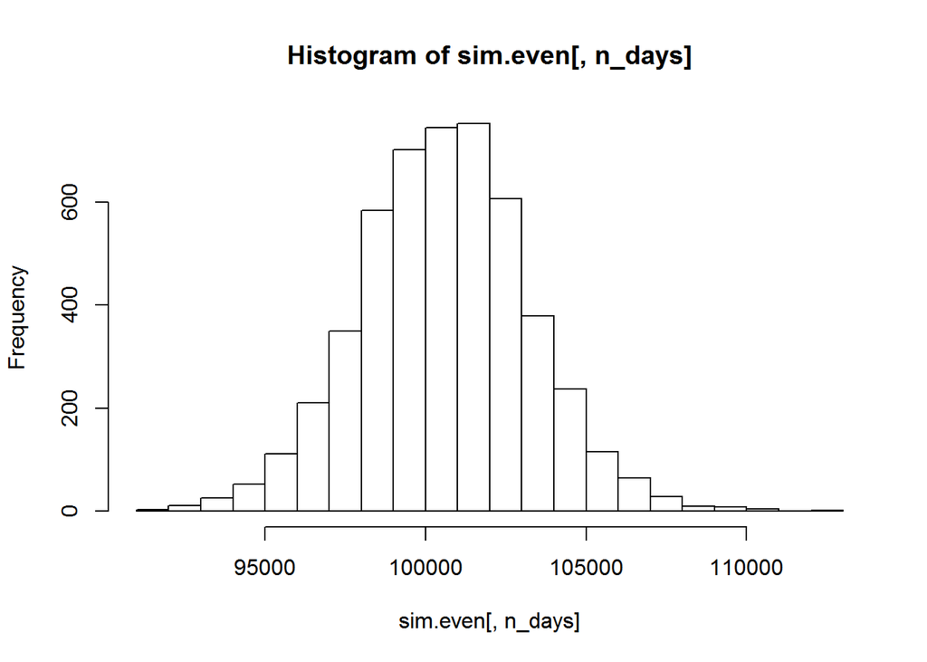

Let’s look at that middle. The below number is the average total wealth at the end of the simulations. Remember that the initial investment was 100,000

```r
mean(sim.even[,n_days])
```

```
## [1] 100603.2
```

And let’s look at the quartiles. This shows us the median result, the middle 50% of results and the best and worst result that occurred in this simulation.

```r
quantile(sim.even[,n_days])
```

```
##       0%      25%      50%      75%     100%
##  91112.9  98862.5 100624.7 102293.9 112658.3
```

And finally if we want to consider the riskiness of this option, we will look at the 5% risk. This tells us what value we can expect to outperform with 95% confidence by taking this investment approach for a given 20 investment day period based on our bootstrap.

```r
quantile(sim.even[,n_days],.05)
```

```
##       5%
## 96309.48
```

Now let us look at the histogram for the safer option sim.safer. We see that it again is concentrated in the middle, if slightly more so.

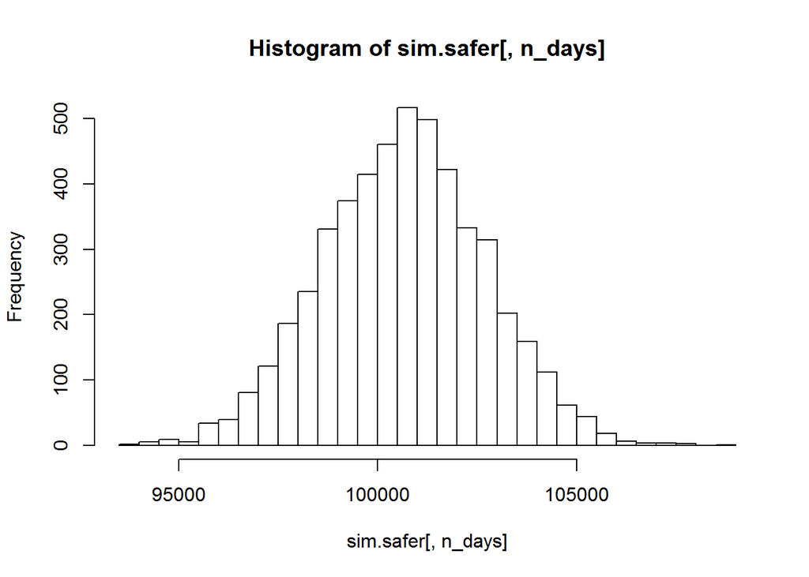

Let’s look at that middle. The below number is the average total wealth at the end of the simulations. Remember that the initial investment was 100,000. The result is comparable to the sim.even mean.

```r
mean(sim.safer[,n_days])
```

```
## [1] 100664
```

So now let’s look at it’s quartiles. This is the first place we can see a clear difference from the even splits. Both the worst and best case scenarios are much less extreme. The 25% and the 75% outcomes are also less extreme. The median outcome is comparable to the original case.

```
##        0%       25%       50%       75%      100%
##  93611.82  99287.60 100694.99 102029.02 108820.35
```

We will also loo at the 5% risk for this safer portfolio. The risk is significanlty reduced with this portfolio as compared to the even splits.

```
##       5%
## 97316.99
```

Finally let’s consider the riskier portfolio and see whehter or not it lives up to it’s name sim.fun. First let us look at it’s histogram. It already has a noticably wider spread than the safer option.

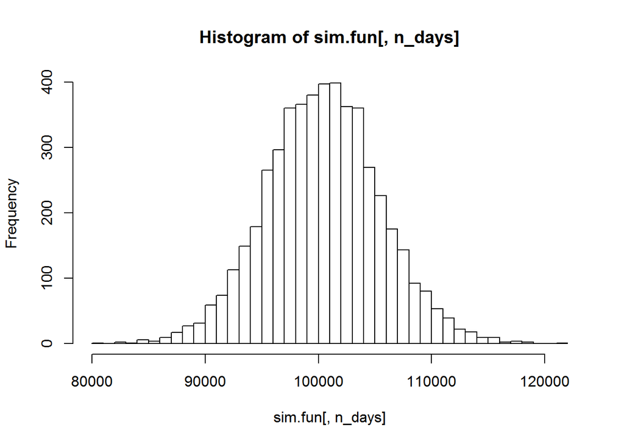

Let’s look closer by first looking for it’s mean. Though not very different, it is noticably a bit lower than the other two portfolios.

```r
mean(sim.fun[,n_days])
```

```
## [1] 100419.5
```

But let’s look further at its quantiles. We can see that risk is far greater in this portfolio. The worst case scenario is very much worse than in the safer portfolio and the best case scenario is much better. It is also a bit more spread out at the middle and seems to skew a little bit towards lower returns.

```
##        0%       25%       50%       75%      100%
##  80741.50  97080.56 100390.42 103727.91 121893.44
```

Finally we will look at the 5% quantile to get a better handle on it’s risk. The gap here is very significan, not just from the safer portfolio but also from the even split portfolio.

```r
quantile(sim.fun[,n_days],.05)
```

```
##       5%
## 92205.69
```

After considering all of this it seems that the portfolio generated by sim.safer is the preferred option of these 3. It renders the equivalent or even better expected returns, both in median and mean, than either other option with significanly less risk.

…………………………………………………………………..

Now from stocks… to wine. We want to see if we can have a computer classify wine by binary color - red or white - given certain properties of the wine. First let us load in the data and view a summary.

```r
wine = read.csv('wine.csv', header=TRUE)
attach(wine)
summary(wine)
```

```
##  fixed.acidity    volatile.acidity  citric.acid     residual.sugar
##  Min.   : 3.800   Min.   :0.0800   Min.   :0.0000   Min.   : 0.600
##  1st Qu.: 6.400   1st Qu.:0.2300   1st Qu.:0.2500   1st Qu.: 1.800
##  Median : 7.000   Median :0.2900   Median :0.3100   Median : 3.000
##  Mean   : 7.215   Mean   :0.3397   Mean   :0.3186   Mean   : 5.443
##  3rd Qu.: 7.700   3rd Qu.:0.4000   3rd Qu.:0.3900   3rd Qu.: 8.100
##  Max.   :15.900   Max.   :1.5800   Max.   :1.6600   Max.   :65.800
##    chlorides       free.sulfur.dioxide total.sulfur.dioxide
##  Min.   :0.00900   Min.   :  1.00      Min.   :  6.0
##  1st Qu.:0.03800   1st Qu.: 17.00      1st Qu.: 77.0
##  Median :0.04700   Median : 29.00      Median :118.0
##  Mean   :0.05603   Mean   : 30.53      Mean   :115.7
##  3rd Qu.:0.06500   3rd Qu.: 41.00      3rd Qu.:156.0
##  Max.   :0.61100   Max.   :289.00      Max.   :440.0
##     density             pH          sulphates         alcohol
##  Min.   :0.9871   Min.   :2.720   Min.   :0.2200   Min.   : 8.00
##  1st Qu.:0.9923   1st Qu.:3.110   1st Qu.:0.4300   1st Qu.: 9.50
##  Median :0.9949   Median :3.210   Median :0.5100   Median :10.30
##  Mean   :0.9947   Mean   :3.219   Mean   :0.5313   Mean   :10.49
##  3rd Qu.:0.9970   3rd Qu.:3.320   3rd Qu.:0.6000   3rd Qu.:11.30
##  Max.   :1.0390   Max.   :4.010   Max.   :2.0000   Max.   :14.90
##     quality        color
##  Min.   :3.000   red  :1599
##  1st Qu.:5.000   white:4898
##  Median :6.000
##  Mean   :5.818
##  3rd Qu.:6.000
##  Max.   :9.000
```

Now we don’t want the computer to include color as a predictor of well color nor are we interested in the subjective variable of quality. So next we will truncate the data and normalise it.

```r
X = wine[,(1:11)]
X = scale(X, center=TRUE, scale=TRUE)
```

Now that that is done we are ready to cluster the data with kmeans. We will selet kmeans as 2 as we are trying to split the wines into a set of white and a set of red. We can choose a very large nstart due to the relative simplicity of this problem.

```r
clust1 = kmeans(X, 2, nstart=2225)
```

Now let us look at a plot of the two clusters. We will create bar plots of the color of the wine. We will also color the portions of each bar by whether they are in cluster 1 or cluster 2. The below plot may be difficult to read, and that is because the clustering did so well that both bars are almost entirely of one cluster!

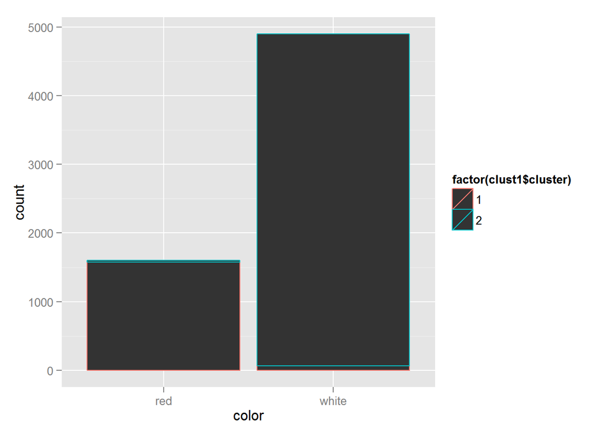

```r
qplot(color, color=factor(clust1$cluster))
```

Now let us look at principal component analysis (PCA) to see how that compares to kmeans in splitting these wines into whites and reds. Let’s use the tools in r to find the principle components and use those to predict the color of the wine.

```r
pc1=prcomp(X)
summary(pc1)
```

```
## Importance of components:
##                           PC1    PC2    PC3     PC4     PC5     PC6
## Standard deviation     1.7407 1.5792 1.2475 0.98517 0.84845 0.77930
## Proportion of Variance 0.2754 0.2267 0.1415 0.08823 0.06544 0.05521
## Cumulative Proportion  0.2754 0.5021 0.6436 0.73187 0.79732 0.85253
##                            PC7     PC8     PC9   PC10    PC11
## Standard deviation     0.72330 0.70817 0.58054 0.4772 0.18119
## Proportion of Variance 0.04756 0.04559 0.03064 0.0207 0.00298
## Cumulative Proportion  0.90009 0.94568 0.97632 0.9970 1.00000
```

Now let us try to visualise how well these principal components split wines across color. We do this with a plot of PC1 scores and PC2 scores where the coloring of points is done by the color of the wine in question.

There appears to be some seperation of whites (shown in blue) from reds (appropriately shown in red) based on principal component, but the split is not as clearly understood visually as it was in the last graph.

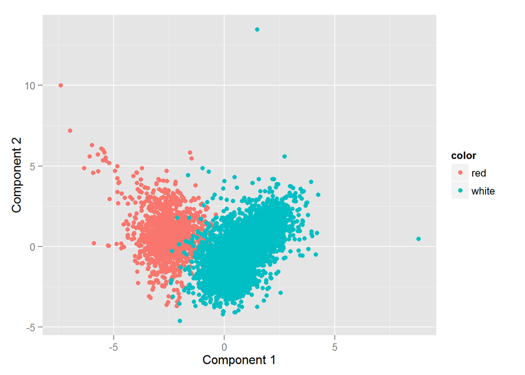

```r
scores = pc1$x
qplot(scores[,1], scores[,2], color=color, xlab='Component 1', ylab='Component 2')
```

So now to compare the two and see whether principal component analysis or kmeans clustering more effectively splits the wines by color, we will use decision trees that use the clusters and principle components respectively to gauge the color of the wine.

First we create and check a decision tree using the cluster. This tree has only one split, and splits a tree by which cluster it is in. And unsuprisingly, it has a very low misclassification rate.

```r
library(tree)
colortree=tree(color~clust1$cluster)
summary(colortree)
```

```
##
## Classification tree:
## tree(formula = color ~ clust1$cluster)
## Number of terminal nodes:  2
## Residual mean deviance:  0.1338 = 869 / 6495
## Misclassification error rate: 0.01416 = 92 / 6497
```

```r
colortree2=tree(color~scores)
summary(colortree2)
```

```
##
## Classification tree:
## tree(formula = color ~ scores)
## Variables actually used in tree construction:
## [1] "scores.PC1"  "scores.PC2"  "scores.PC11"
## Number of terminal nodes:  6
## Residual mean deviance:  0.103 = 668.3 / 6491
## Misclassification error rate: 0.01324 = 86 / 6497
```

……………………………………………………………………..

Vitamin Water has gathered a lot of data about social media accounts. To start, we must load the appropriate data.

```r
vitwater = read.csv('social_marketing.csv', header=TRUE)
summary(vitwater)
```

```
##          X           chatter       current_events      travel
##  123pxkyqj:   1   Min.   : 0.000   Min.   :0.000   Min.   : 0.000
##  12grikctu:   1   1st Qu.: 2.000   1st Qu.:1.000   1st Qu.: 0.000
##  12klxic7j:   1   Median : 3.000   Median :1.000   Median : 1.000
##  12t4msroj:   1   Mean   : 4.399   Mean   :1.526   Mean   : 1.585
##  12yam59l3:   1   3rd Qu.: 6.000   3rd Qu.:2.000   3rd Qu.: 2.000
##  132y8f6aj:   1   Max.   :26.000   Max.   :8.000   Max.   :26.000
##  (Other)  :7876
##  photo_sharing    uncategorized      tv_film      sports_fandom
##  Min.   : 0.000   Min.   :0.000   Min.   : 0.00   Min.   : 0.000
##  1st Qu.: 1.000   1st Qu.:0.000   1st Qu.: 0.00   1st Qu.: 0.000
##  Median : 2.000   Median :1.000   Median : 1.00   Median : 1.000
##  Mean   : 2.697   Mean   :0.813   Mean   : 1.07   Mean   : 1.594
##  3rd Qu.: 4.000   3rd Qu.:1.000   3rd Qu.: 1.00   3rd Qu.: 2.000
##  Max.   :21.000   Max.   :9.000   Max.   :17.00   Max.   :20.000
##
##     politics           food            family        home_and_garden
##  Min.   : 0.000   Min.   : 0.000   Min.   : 0.0000   Min.   :0.0000
##  1st Qu.: 0.000   1st Qu.: 0.000   1st Qu.: 0.0000   1st Qu.:0.0000
##  Median : 1.000   Median : 1.000   Median : 1.0000   Median :0.0000
##  Mean   : 1.789   Mean   : 1.397   Mean   : 0.8639   Mean   :0.5207
##  3rd Qu.: 2.000   3rd Qu.: 2.000   3rd Qu.: 1.0000   3rd Qu.:1.0000
##  Max.   :37.000   Max.   :16.000   Max.   :10.0000   Max.   :5.0000
##
##      music              news        online_gaming       shopping
##  Min.   : 0.0000   Min.   : 0.000   Min.   : 0.000   Min.   : 0.000
##  1st Qu.: 0.0000   1st Qu.: 0.000   1st Qu.: 0.000   1st Qu.: 0.000
##  Median : 0.0000   Median : 0.000   Median : 0.000   Median : 1.000
##  Mean   : 0.6793   Mean   : 1.206   Mean   : 1.209   Mean   : 1.389
##  3rd Qu.: 1.0000   3rd Qu.: 1.000   3rd Qu.: 1.000   3rd Qu.: 2.000
##  Max.   :13.0000   Max.   :20.000   Max.   :27.000   Max.   :12.000
##
##  health_nutrition  college_uni     sports_playing      cooking
##  Min.   : 0.000   Min.   : 0.000   Min.   :0.0000   Min.   : 0.000
##  1st Qu.: 0.000   1st Qu.: 0.000   1st Qu.:0.0000   1st Qu.: 0.000
##  Median : 1.000   Median : 1.000   Median :0.0000   Median : 1.000
##  Mean   : 2.567   Mean   : 1.549   Mean   :0.6392   Mean   : 1.998
##  3rd Qu.: 3.000   3rd Qu.: 2.000   3rd Qu.:1.0000   3rd Qu.: 2.000
##  Max.   :41.000   Max.   :30.000   Max.   :8.0000   Max.   :33.000
##
```

[output cut: 25 more lines]

```
##  Min.   : 0.000   Min.   : 0.0000   Min.   :0.0000   Min.   :0.00000
##  1st Qu.: 0.000   1st Qu.: 0.0000   1st Qu.:0.0000   1st Qu.:0.00000
##  Median : 0.000   Median : 0.0000   Median :0.0000   Median :0.00000
##  Mean   : 1.462   Mean   : 0.9966   Mean   :0.3363   Mean   :0.00647
##  3rd Qu.: 2.000   3rd Qu.: 1.0000   3rd Qu.:1.0000   3rd Qu.:0.00000
##  Max.   :19.000   Max.   :18.0000   Max.   :6.0000   Max.   :2.00000
##
##      adult
##  Min.   : 0.0000
##  1st Qu.: 0.0000
##  Median : 0.0000
##  Mean   : 0.4033
##  3rd Qu.: 0.0000
##  Max.   :26.0000
##
```

Vitamin water does not target bots so first we remove the profiles that frequently post spam. We can do this by sampling clustering groups based soley on spam removing this group. You can see that after doing this, the spam max drops to 0. At the same time some adult content is removed, the remaining users likely being real people.

```r
vitx=vitwater[,36]
vitx = scale(vitx, center=TRUE, scale=TRUE)

consumer_groups=kmeans(vitx,2, nstart = 4000)
consumer_groups$centers
```

```
##          [,1]
## 1 -0.07768727
## 2 12.41886450
```

```r
vitwater=vitwater[-which(consumer_groups$cluster == 2),]

summary(vitwater)
```

```
##          X           chatter       current_events      travel
##  123pxkyqj:   1   Min.   : 0.000   Min.   :0.000   Min.   : 0.000
##  12grikctu:   1   1st Qu.: 2.000   1st Qu.:1.000   1st Qu.: 0.000
##  12klxic7j:   1   Median : 3.000   Median :1.000   Median : 1.000
##  12t4msroj:   1   Mean   : 4.397   Mean   :1.524   Mean   : 1.581
##  12yam59l3:   1   3rd Qu.: 6.000   3rd Qu.:2.000   3rd Qu.: 2.000
##  132y8f6aj:   1   Max.   :26.000   Max.   :8.000   Max.   :26.000
##  (Other)  :7827
##  photo_sharing    uncategorized       tv_film       sports_fandom
##  Min.   : 0.000   Min.   :0.0000   Min.   : 0.000   Min.   : 0.000
##  1st Qu.: 1.000   1st Qu.:0.0000   1st Qu.: 0.000   1st Qu.: 0.000
##  Median : 2.000   Median :1.0000   Median : 1.000   Median : 1.000
##  Mean   : 2.698   Mean   :0.8123   Mean   : 1.071   Mean   : 1.592
##  3rd Qu.: 4.000   3rd Qu.:1.0000   3rd Qu.: 1.000   3rd Qu.: 2.000
##  Max.   :21.000   Max.   :9.0000   Max.   :17.000   Max.   :20.000
##
##     politics           food            family        home_and_garden
##  Min.   : 0.000   Min.   : 0.000   Min.   : 0.0000   Min.   :0.0000
##  1st Qu.: 0.000   1st Qu.: 0.000   1st Qu.: 0.0000   1st Qu.:0.0000
##  Median : 1.000   Median : 1.000   Median : 1.0000   Median :0.0000
##  Mean   : 1.786   Mean   : 1.397   Mean   : 0.8643   Mean   :0.5196
##  3rd Qu.: 2.000   3rd Qu.: 2.000   3rd Qu.: 1.0000   3rd Qu.:1.0000
##  Max.   :37.000   Max.   :16.000   Max.   :10.0000   Max.   :5.0000
##
##      music              news        online_gaming       shopping
##  Min.   : 0.0000   Min.   : 0.000   Min.   : 0.000   Min.   : 0.000
##  1st Qu.: 0.0000   1st Qu.: 0.000   1st Qu.: 0.000   1st Qu.: 0.000
##  Median : 0.0000   Median : 0.000   Median : 0.000   Median : 1.000
##  Mean   : 0.6792   Mean   : 1.206   Mean   : 1.207   Mean   : 1.392
##  3rd Qu.: 1.0000   3rd Qu.: 1.000   3rd Qu.: 1.000   3rd Qu.: 2.000
##  Max.   :13.0000   Max.   :20.000   Max.   :27.000   Max.   :12.000
##
##  health_nutrition  college_uni     sports_playing      cooking
##  Min.   : 0.000   Min.   : 0.000   Min.   :0.0000   Min.   : 0.000
##  1st Qu.: 0.000   1st Qu.: 0.000   1st Qu.:0.0000   1st Qu.: 0.000
##  Median : 1.000   Median : 1.000   Median :0.0000   Median : 1.000
##  Mean   : 2.566   Mean   : 1.547   Mean   :0.6399   Mean   : 1.999
##  3rd Qu.: 3.000   3rd Qu.: 2.000   3rd Qu.:1.0000   3rd Qu.: 2.000
##  Max.   :41.000   Max.   :30.000   Max.   :8.0000   Max.   :33.000
##
```

[output cut: 25 more lines]

```
##  Min.   : 0.00    Min.   : 0.0000   Min.   :0.0000   Min.   :0
##  1st Qu.: 0.00    1st Qu.: 0.0000   1st Qu.:0.0000   1st Qu.:0
##  Median : 0.00    Median : 0.0000   Median :0.0000   Median :0
##  Mean   : 1.46    Mean   : 0.9968   Mean   :0.3351   Mean   :0
##  3rd Qu.: 2.00    3rd Qu.: 1.0000   3rd Qu.:1.0000   3rd Qu.:0
##  Max.   :19.00    Max.   :18.0000   Max.   :6.0000   Max.   :0
##
##      adult
##  Min.   : 0.0000
##  1st Qu.: 0.0000
##  Median : 0.0000
##  Mean   : 0.3608
##  3rd Qu.: 0.0000
##  Max.   :26.0000
##
```

One can fairly assess that Vitamin Water’s targeted consumers will be interested in certain categories: sports, nutrition, fitness and more. Now with this cleaner data, we should look for what groups may exist that fit Vitamin Water’s target consumer. We exclude spam and adult data as those are not categories with which Vitamin Water wants to be associated

```r
vitx=vitwater[,2:35]
vitx=scale(vitx, center=TRUE, scale=TRUE)
set.rseed(1)
consumer_groups=kmeans(vitx,5, nstart = 500)
consumer_groups$centers
```

```
##        chatter current_events      travel photo_sharing uncategorized
## 1 -0.003197032     0.09951844  1.83616554   -0.10438040   -0.03854249
## 2 -0.210253163    -0.12828558 -0.23314710   -0.31444618   -0.16575848
## 3  0.712401554     0.27608219 -0.03529165    1.03562890    0.45743094
## 4 -0.087988196     0.11897186 -0.09780516   -0.06410703   -0.07749408
## 5 -0.075711977    -0.01309044 -0.15371943   -0.04580766    0.14402394
##        tv_film sports_fandom   politics        food      family
## 1  0.031996908     0.1966383  2.4278101  0.03342804  0.05347040
## 2 -0.150462066    -0.2971209 -0.2723559 -0.36547381 -0.27184104
## 3  0.493432243    -0.1643370 -0.1288060 -0.15359375  0.03780228
## 4  0.001826717     2.0435440 -0.1984974  1.81734786  1.49745277
## 5 -0.108888196    -0.2007623 -0.1826013  0.42532318 -0.07618181
##   home_and_garden       music        news online_gaming      shopping
## 1       0.1222329 -0.05146997  1.94212836   -0.08550502 -0.0565040304
## 2      -0.1711119 -0.20341585 -0.24856468   -0.12939884 -0.2419146951
```

[output cut: 27 more lines]

Two groups are of particular interest.

First there are sports enthusiasts. They are also likely to tweeet about food, family, religion, parenting and school. This insight may inform Vitamin Water about marketing strategies to attract sports fans to the brand. Potential avenues may be advertising during sporting events encouraging parents to give their children Vitamin Water for school and organised sports.

```
##   sports_fandom   politics
## 1     0.1966383  2.4278101
## 2    -0.2971209 -0.2723559
## 3    -0.1643370 -0.1288060
## 4     2.0435440 -0.1984974
## 5    -0.2007623 -0.1826013
```

```
##          food      family
## 1  0.03342804  0.05347040
## 2 -0.36547381 -0.27184104
## 3 -0.15359375  0.03780228
## 4  1.81734786  1.49745277
## 5  0.42532318 -0.07618181
```

```
##      religion     beauty   parenting      dating     school
## 1 -0.03030892 -0.1503519  0.02830241  0.20512339 -0.0402543
## 2 -0.30378545 -0.2894138 -0.31145036 -0.16589266 -0.3033604
## 3 -0.16486326  0.8620468 -0.14006970  0.28741135  0.1502772
## 4  2.25011603  0.3127336  2.11849309 -0.01117011  1.6502564
## 5 -0.16958803 -0.1682775 -0.10638828  0.17765545 -0.1662583
```

Second we will look at the tweeters interested in personal fitness and nutrition

This group is much harder to pin down. Beyond an interest in personal fitness and nutrition, the only other very strong tendency is to make post about the outdoors. Not as strong is their tendency to post ecological tweets but they are the group most likely to be make eco tweets. It is reasonable to infer that in communicating with these target consumers, ads that feature healthy people in natural environments or promote green initiatives of the brand are likely to connect with these consumers.

```
##   health_nutrition college_uni sports_playing     cooking         eco
## 1       -0.2060133 -0.04016448     0.02901032 -0.19240583  0.09449897
## 2       -0.3286698 -0.15816595    -0.20690675 -0.34020131 -0.23791279
## 3       -0.1818199  0.59945345     0.50847117  0.86770554  0.23871715
## 4       -0.1535855 -0.03034507     0.14271531 -0.08713051  0.18121669
## 5        2.1527614 -0.16162727     0.01882452  0.43683236  0.52197475
##      outdoors     school personal_fitness
## 1  0.10968579 -0.0402543      -0.19701552
## 2 -0.31564118 -0.3033604      -0.34324899
## 3 -0.11450518  0.1502772      -0.14718582
## 4 -0.06500113  1.6502564      -0.09616315
## 5  1.66407611 -0.1662583       2.11047179
```

Other paths were considered. It was considered possible that perhaps target customers (those who tweet about sports, health and fitness) could be predicted based on PCA of non targeted tweets: those not about sports health and fitness. In tests, it was found that this method had very high error rates compared to guessing. For example, when just considering the top 10% of tweeters in the targeted categories, the error rate of a decision tree based on PCA ran higher than 6%. Guessing should result in a 10% error rate so 6% was not considered a strong enough indicator.

It thus suggested that when seeking targeted consumers, tracking target tweet categories such as sports and health should be the focus and non target categories will not do much to inform Vitamin Water of what twitter accounts may be target consumers.